# Real GDP per capita rate vs real GDP rate vs population

Joaquín Rodrigo Ponce de León Conconi

5/28/2021

The purpose of this project is to analyze the real gross domestic product of Mexico, and its rate, at constant prices of 2013 (Mexican pesos), and to analyze the relationship between this variable and the real GDP per capita. The following is the wrangling and analysis process.

In order to upload the datasets and to accomplish a proper analysis, we need to call the libraries tidyverse and readxl.

```r
library(readxl)
library(tidyverse)
```

The file is uploaded and analyzed (The reference of the file can be viewed in the Reference list below).

```r
raw <- read_excel("PIBTR_2.xlsx", )
```

```
## * `` -> ...3
## * `` -> ...4
## * `` -> ...5
## * `` -> ...6
## * `` -> ...7
## * ...
```

```r
df_raw <- as.data.frame(raw) #We change the tibble into a data frame
head(df_raw) #Observe the first six rows
```

|  | Concepto | 1980 | ...3 | ...4 | ...5 | ...6 | ...7 | ...8 | 1981 | ...10 | ...11 | ...12 | ...13 | ...14 | ...15 | 1982 | ...17 | ...18 | ...19 | ...20 | ...21 | ...22 | 1983 | ...24 | ...25 | ...26 | ...27 | ...28 | ...29 | … |
| --- | --- | --- | --- | --- | --- | --- | --- | --- | --- | --- | --- | --- | --- | --- | --- | --- | --- | --- | --- | --- | --- | --- | --- | --- | --- | --- | --- | --- | --- | --- |
| 1 | NA | T1 | T2 | T3 | T4 | 6 Meses | 9 Meses | Anual | T1 | T2 | T3 | T4 | 6 Meses | 9 Meses | Anual | T1 | T2 | T3 | T4 | 6 Meses | 9 Meses | Anual | T1 | T2 | T3 | T4 | 6 Meses | 9 Meses | Anual | … |
| 2 | __abB.1bP - Producto interno bruto | 7547882.1440000003 | 7536518.9919999996 | 7478780.8200000003 | 8008666.6399999997 | 7542200.568 | 7521060.6519999998 | 7642962.1490000002 | 8229212.7019999996 | 8417818.0040000007 | 8211045.5269999998 | 8614524.8650000002 | 8323515.3530000001 | 8286025.4110000003 | 8368150.2750000004 | 8512096.4000000004 | 8481760.7589999996 | 8198953.8990000002 | 8277251.6890000002 | 8496928.5800000001 | 8397603.6860000007 | 8367515.6869999999 | 8120479.8499999996 | 7997531.1169999996 | 7764430.8439999996 | 8127328.5880000005 | 8059005.4840000002 | 7960813.9369999999 | 8002442.5999999996 | … |
| 3 | D.21-D.31 - Impuestos sobre los productos, netos | 282092.93900000001 | 281668.255 | 279510.36099999998 | 299314.201 | 281880.59700000001 | 281090.51799999998 | 285646.43900000001 | 307556.84299999999 | 314605.73700000002 | 306877.86700000003 | 321957.41700000002 | 311081.28999999998 | 309680.14899999998 | 312749.46600000001 | 318129.27799999999 | 316995.52 | 306425.95699999999 | 309352.24200000003 | 317562.39899999998 | 313850.25199999998 | 312725.74900000001 | 303493.08399999997 | 298898.02399999998 | 290186.18400000001 | 303749.04700000002 | 301195.554 | 297525.76400000002 | 299081.58500000002 | … |
| 4 | __cdB.1bV - Valor agregado bruto | 7265789.2050000001 | 7254850.7369999997 | 7199270.4589999998 | 7709352.4390000002 | 7260319.9709999999 | 7239970.1339999996 | 7357315.71 | 7921655.8590000002 | 8103212.267 | 7904167.6600000001 | 8292567.4479999999 | 8012434.0630000001 | 7976345.2620000001 | 8055400.8090000004 | 8193967.1220000004 | 8164765.2390000001 | 7892527.9419999998 | 7967899.4469999997 | 8179366.1809999999 | 8083753.4340000004 | 8054789.9380000001 | 7816986.7659999998 | 7698633.0930000003 | 7474244.6600000001 | 7823579.5410000002 | 7757809.9299999997 | 7663288.1730000004 | 7703361.0149999997 | … |
| 5 | Actividades primarias | 320667.549 | 287579.26799999998 | 304948.75099999999 | 316649.93199999997 | 304123.40899999999 | 304398.52299999999 | 307461.375 | 335400.962 | 317798.02299999999 | 322028.033 | 350034.52 | 326599.49300000002 | 325075.67300000001 | 331315.38500000001 | 355697.185 | 327458.89899999998 | 302562.62 | 309605.31599999999 | 341578.04200000002 | 328572.90100000001 | 323831.005 | 337303.33899999998 | 315329.01799999998 | 313931.603 | 354682.58600000001 | 326316.179 | 322187.98700000002 | 330311.63699999999 | … |
| 6 | Actividades secundarias | 2864062.9 | 2877701.6519999998 | 2935853.3149999999 | 3037769.9619999998 | 2870882.2760000001 | 2892539.2889999999 | 2928846.9569999999 | 3142427.449 | 3286989.0789999999 | 3312083.3459999999 | 3270025.048 | 3214708.264 | 3247166.625 | 3252881.2310000001 | 3269031.173 | 3294492.0460000001 | 3236595.5729999999 | 3070717.2940000002 | 3281761.61 | 3266706.264 | 3217709.0219999999 | 2905809.14 | 2914584.56 | 2898295.4019999998 | 2913668.5920000002 | 2910196.85 | 2906229.7009999999 | 2908089.4240000001 | … |

```r
tail(df_raw) #Observe the first six rows
```

|  | Concepto | 1980 | ...3 | ...4 | ...5 | ...6 | ...7 | ...8 | 1981 | ...10 | ...11 | ...12 | ...13 | ...14 | ...15 | 1982 | ...17 | ...18 | ...19 | ...20 | ...21 | ...22 | 1983 | ...24 | ...25 | ...26 | ...27 | ...28 | ...29 | … |
| --- | --- | --- | --- | --- | --- | --- | --- | --- | --- | --- | --- | --- | --- | --- | --- | --- | --- | --- | --- | --- | --- | --- | --- | --- | --- | --- | --- | --- | --- | --- |
| 2 | __abB.1bP - Producto interno bruto | 7547882.1440000003 | 7536518.9919999996 | 7478780.8200000003 | 8008666.6399999997 | 7542200.568 | 7521060.6519999998 | 7642962.1490000002 | 8229212.7019999996 | 8417818.0040000007 | 8211045.5269999998 | 8614524.8650000002 | 8323515.3530000001 | 8286025.4110000003 | 8368150.2750000004 | 8512096.4000000004 | 8481760.7589999996 | 8198953.8990000002 | 8277251.6890000002 | 8496928.5800000001 | 8397603.6860000007 | 8367515.6869999999 | 8120479.8499999996 | 7997531.1169999996 | 7764430.8439999996 | 8127328.5880000005 | 8059005.4840000002 | 7960813.9369999999 | 8002442.5999999996 | … |
| 3 | D.21-D.31 - Impuestos sobre los productos, netos | 282092.93900000001 | 281668.255 | 279510.36099999998 | 299314.201 | 281880.59700000001 | 281090.51799999998 | 285646.43900000001 | 307556.84299999999 | 314605.73700000002 | 306877.86700000003 | 321957.41700000002 | 311081.28999999998 | 309680.14899999998 | 312749.46600000001 | 318129.27799999999 | 316995.52 | 306425.95699999999 | 309352.24200000003 | 317562.39899999998 | 313850.25199999998 | 312725.74900000001 | 303493.08399999997 | 298898.02399999998 | 290186.18400000001 | 303749.04700000002 | 301195.554 | 297525.76400000002 | 299081.58500000002 | … |
| 4 | __cdB.1bV - Valor agregado bruto | 7265789.2050000001 | 7254850.7369999997 | 7199270.4589999998 | 7709352.4390000002 | 7260319.9709999999 | 7239970.1339999996 | 7357315.71 | 7921655.8590000002 | 8103212.267 | 7904167.6600000001 | 8292567.4479999999 | 8012434.0630000001 | 7976345.2620000001 | 8055400.8090000004 | 8193967.1220000004 | 8164765.2390000001 | 7892527.9419999998 | 7967899.4469999997 | 8179366.1809999999 | 8083753.4340000004 | 8054789.9380000001 | 7816986.7659999998 | 7698633.0930000003 | 7474244.6600000001 | 7823579.5410000002 | 7757809.9299999997 | 7663288.1730000004 | 7703361.0149999997 | … |
| 5 | Actividades primarias | 320667.549 | 287579.26799999998 | 304948.75099999999 | 316649.93199999997 | 304123.40899999999 | 304398.52299999999 | 307461.375 | 335400.962 | 317798.02299999999 | 322028.033 | 350034.52 | 326599.49300000002 | 325075.67300000001 | 331315.38500000001 | 355697.185 | 327458.89899999998 | 302562.62 | 309605.31599999999 | 341578.04200000002 | 328572.90100000001 | 323831.005 | 337303.33899999998 | 315329.01799999998 | 313931.603 | 354682.58600000001 | 326316.179 | 322187.98700000002 | 330311.63699999999 | … |
| 6 | Actividades secundarias | 2864062.9 | 2877701.6519999998 | 2935853.3149999999 | 3037769.9619999998 | 2870882.2760000001 | 2892539.2889999999 | 2928846.9569999999 | 3142427.449 | 3286989.0789999999 | 3312083.3459999999 | 3270025.048 | 3214708.264 | 3247166.625 | 3252881.2310000001 | 3269031.173 | 3294492.0460000001 | 3236595.5729999999 | 3070717.2940000002 | 3281761.61 | 3266706.264 | 3217709.0219999999 | 2905809.14 | 2914584.56 | 2898295.4019999998 | 2913668.5920000002 | 2910196.85 | 2906229.7009999999 | 2908089.4240000001 | … |
| 7 | Actividades terciarias | 4081058.7560000001 | 4089569.8169999998 | 3958468.3930000002 | 4354932.5449999999 | 4085314.287 | 4043032.3220000002 | 4121007.378 | 4443827.4479999999 | 4498425.165 | 4270056.2810000004 | 4672507.88 | 4471126.307 | 4404102.9649999999 | 4471204.1940000001 | 4569238.7640000004 | 4542814.2939999998 | 4353369.7489999998 | 4587576.8370000003 | 4556026.5290000001 | 4488474.2690000003 | 4513249.9110000003 | 4573874.2869999995 | 4468719.5149999997 | 4262017.6550000003 | 4555228.3629999999 | 4521296.9009999996 | 4434870.4859999996 | 4464959.9550000001 | … |

```r
names(df_raw) #Know the column names
```

```
##   [1] "Concepto" "1980"     "...3"     "...4"     "...5"     "...6"
##   [7] "...7"     "...8"     "1981"     "...10"    "...11"    "...12"
##  [13] "...13"    "...14"    "...15"    "1982"     "...17"    "...18"
##  [19] "...19"    "...20"    "...21"    "...22"    "1983"     "...24"
##  [25] "...25"    "...26"    "...27"    "...28"    "...29"    "1984"
##  [31] "...31"    "...32"    "...33"    "...34"    "...35"    "...36"
##  [37] "1985"     "...38"    "...39"    "...40"    "...41"    "...42"
##  [43] "...43"    "1986"     "...45"    "...46"    "...47"    "...48"
##  [49] "...49"    "...50"    "1987"     "...52"    "...53"    "...54"
##  [55] "...55"    "...56"    "...57"    "1988"     "...59"    "...60"
##  [61] "...61"    "...62"    "...63"    "...64"    "1989"     "...66"
##  [67] "...67"    "...68"    "...69"    "...70"    "...71"    "1990"
##  [73] "...73"    "...74"    "...75"    "...76"    "...77"    "...78"
##  [79] "1991"     "...80"    "...81"    "...82"    "...83"    "...84"
##  [85] "...85"    "1992"     "...87"    "...88"    "...89"    "...90"
```

[output cut: 35 more lines]

```r
str(df_raw) #Know the structure of the dataset
```

```
## 'data.frame':    7 obs. of  295 variables:
##  $ Concepto: chr  NA "__abB.1bP - Producto interno bruto" "D.21-D.31 - Impuestos sobre los productos, netos" "__cdB.1bV - Valor agregado bruto" ...
##  $ 1980    : chr  "T1" "7547882.1440000003" "282092.93900000001" "7265789.2050000001" ...
##  $ ...3    : chr  "T2" "7536518.9919999996" "281668.255" "7254850.7369999997" ...
##  $ ...4    : chr  "T3" "7478780.8200000003" "279510.36099999998" "7199270.4589999998" ...
##  $ ...5    : chr  "T4" "8008666.6399999997" "299314.201" "7709352.4390000002" ...
##  $ ...6    : chr  "6 Meses" "7542200.568" "281880.59700000001" "7260319.9709999999" ...
##  $ ...7    : chr  "9 Meses" "7521060.6519999998" "281090.51799999998" "7239970.1339999996" ...
##  $ ...8    : chr  "Anual" "7642962.1490000002" "285646.43900000001" "7357315.71" ...
##  $ 1981    : chr  "T1" "8229212.7019999996" "307556.84299999999" "7921655.8590000002" ...
##  $ ...10   : chr  "T2" "8417818.0040000007" "314605.73700000002" "8103212.267" ...
##  $ ...11   : chr  "T3" "8211045.5269999998" "306877.86700000003" "7904167.6600000001" ...
##  $ ...12   : chr  "T4" "8614524.8650000002" "321957.41700000002" "8292567.4479999999" ...
##  $ ...13   : chr  "6 Meses" "8323515.3530000001" "311081.28999999998" "8012434.0630000001" ...
##  $ ...14   : chr  "9 Meses" "8286025.4110000003" "309680.14899999998" "7976345.2620000001" ...
```

[output cut: 86 more lines]

We see that the first row has the names “T1”, “T2”, “T3”, “T4”, “6 Meses”, “9 Meses”, and “Anual”. Our aim is to get the data from the second column (__abB.1bP - Producto interno bruto), which the real gross DOMESTIC product from Mexico, and the data that is stored in “Anual” (Anual means Annual in Spanish). So, we are basically extracting the annual real GDP from different years.

```r
#We extract the first 2 rows
df_raw12 <- df_raw[1:2,]
head(df_raw12) #Let's check how it looks
```

|  | Concepto | 1980 | ...3 | ...4 | ...5 | ...6 | ...7 | ...8 | 1981 | ...10 | ...11 | ...12 | ...13 | ...14 | ...15 | 1982 | ...17 | ...18 | ...19 | ...20 | ...21 | ...22 | 1983 | ...24 | ...25 | ...26 | ...27 | ...28 | ...29 | … |
| --- | --- | --- | --- | --- | --- | --- | --- | --- | --- | --- | --- | --- | --- | --- | --- | --- | --- | --- | --- | --- | --- | --- | --- | --- | --- | --- | --- | --- | --- | --- |
| 1 | NA | T1 | T2 | T3 | T4 | 6 Meses | 9 Meses | Anual | T1 | T2 | T3 | T4 | 6 Meses | 9 Meses | Anual | T1 | T2 | T3 | T4 | 6 Meses | 9 Meses | Anual | T1 | T2 | T3 | T4 | 6 Meses | 9 Meses | Anual | … |
| 2 | __abB.1bP - Producto interno bruto | 7547882.1440000003 | 7536518.9919999996 | 7478780.8200000003 | 8008666.6399999997 | 7542200.568 | 7521060.6519999998 | 7642962.1490000002 | 8229212.7019999996 | 8417818.0040000007 | 8211045.5269999998 | 8614524.8650000002 | 8323515.3530000001 | 8286025.4110000003 | 8368150.2750000004 | 8512096.4000000004 | 8481760.7589999996 | 8198953.8990000002 | 8277251.6890000002 | 8496928.5800000001 | 8397603.6860000007 | 8367515.6869999999 | 8120479.8499999996 | 7997531.1169999996 | 7764430.8439999996 | 8127328.5880000005 | 8059005.4840000002 | 7960813.9369999999 | 8002442.5999999996 | … |

```r
#To make the wrangling easier, let's change the row names
rownames(df_raw12) <- c("Season", "GDP")
#Let's select all the columns except the first one
df_raw12 <- df_raw12 %>% select(-Concepto)
#We elongate the data set with only the real GDP
df_raw2_l <- gather(df_raw12[2,], key = "Period", value = "GDP")
df_raw2_l <- transform(df_raw2_l, GDP = as.numeric(GDP)) #We transform GDP to numeric
head(df_raw2_l) #We see how it looks
```

|  | Period | GDP |
| --- | --- | --- |
| 1 | 1980 | 7547882 |
| 2 | ...3 | 7536519 |
| 3 | ...4 | 7478781 |
| 4 | ...5 | 8008667 |
| 5 | ...6 | 7542201 |
| 6 | ...7 | 7521061 |

```r
#We do the same for row 1
df_raw1_l <- gather(df_raw12[1,], key = "Period", value = "Season")
head(df_raw1_l)
```

|  | Period | Season |
| --- | --- | --- |
| 1 | 1980 | T1 |
| 2 | ...3 | T2 |
| 3 | ...4 | T3 |
| 4 | ...5 | T4 |
| 5 | ...6 | 6 Meses |
| 6 | ...7 | 9 Meses |

Now that we have df_raw1_l and df_raw2_l, we do the final data wrangling.

```r
#Both variables need to have the same structure (294 obs. of 2 variables)
str(df_raw1_l)
```

```
## 'data.frame':    294 obs. of  2 variables:
##  $ Period: chr  "1980" "...3" "...4" "...5" ...
##  $ Season: chr  "T1" "T2" "T3" "T4" ...
```

```r
str(df_raw2_l)
```

```
## 'data.frame':    294 obs. of  2 variables:
##  $ Period: chr  "1980" "...3" "...4" "...5" ...
##  $ GDP   : num  7547882 7536519 7478781 8008667 7542201 ...
```

```r
#Let's check (just to be sure) if the Period column for both variables is identical
identical(df_raw1_l[,1], df_raw2_l[,1])
```

```
## [1] TRUE
```

```r
#It is, and therefore we can make a new data frame that contains Period, GDP, and Season
r_gdp <- cbind(df_raw2_l, df_raw1_l[,2])#We bind the columns
colnames(r_gdp) <- c("Period", "GDP", "Season") #We set the column names
factor(r_gdp[,3]) #We factor the third column to see if "Anual" is written in the same format
```

```
##   [1] T1      T2      T3      T4      6 Meses 9 Meses Anual   T1      T2
##  [10] T3      T4      6 Meses 9 Meses Anual   T1      T2      T3      T4
##  [19] 6 Meses 9 Meses Anual   T1      T2      T3      T4      6 Meses 9 Meses
##  [28] Anual   T1      T2      T3      T4      6 Meses 9 Meses Anual   T1
##  [37] T2      T3      T4      6 Meses 9 Meses Anual   T1      T2      T3
##  [46] T4      6 Meses 9 Meses Anual   T1      T2      T3      T4      6 Meses
##  [55] 9 Meses Anual   T1      T2      T3      T4      6 Meses 9 Meses Anual
##  [64] T1      T2      T3      T4      6 Meses 9 Meses Anual   T1      T2
##  [73] T3      T4      6 Meses 9 Meses Anual   T1      T2      T3      T4
##  [82] 6 Meses 9 Meses Anual   T1      T2      T3      T4      6 Meses 9 Meses
##  [91] Anual   T1      T2      T3      T4      6 Meses 9 Meses Anual   T1
## [100] T2      T3      T4      6 Meses 9 Meses Anual   T1      T2      T3
## [109] T4      6 Meses 9 Meses Anual   T1      T2      T3      T4      6 Meses
## [118] 9 Meses Anual   T1      T2      T3      T4      6 Meses 9 Meses Anual
## [127] T1      T2      T3      T4      6 Meses 9 Meses Anual   T1      T2
```

[output cut: 19 more lines]

```r
#Now we filter the data to only include the Annual data
r_gdp <- r_gdp %>% filter(Season=="Anual") %>% select(-Season)
str(r_gdp)
```

```
## 'data.frame':    42 obs. of  2 variables:
##  $ Period: chr  "...8" "...15" "...22" "...29" ...
##  $ GDP   : num  7642962 8368150 8367516 8002443 8281465 ...
```

```r
head(r_gdp)
```

|  | Period | GDP |
| --- | --- | --- |
| 1 | ...8 | 7642962 |
| 2 | ...15 | 8368150 |
| 3 | ...22 | 8367516 |
| 4 | ...29 | 8002443 |
| 5 | ...36 | 8281465 |
| 6 | ...43 | 8437038 |

```r
tail(r_gdp)
```

|  | Period | GDP |
| --- | --- | --- |
| 37 | ...260 | 17747239 |
| 38 | ...267 | 18122261 |
| 39 | ...274 | 18520044 |
| 40 | ...281 | 18487338 |
| 41 | ...288 | 16951218 |
| 42 | ...295 | NA |

```r
#Previously we saw that the period was from 1980 to 2021, so let's change the Period column
Period <- 1980:2021 #We create a variable with the proper years to bind it to the dataset
r_gdp <- r_gdp %>% select(-Period)#We select all the columns except Period
r_gdp <- cbind(Period, r_gdp)
head(r_gdp)
```

|  | Period | GDP |
| --- | --- | --- |
| 1 | 1980 | 7642962 |
| 2 | 1981 | 8368150 |
| 3 | 1982 | 8367516 |
| 4 | 1983 | 8002443 |
| 5 | 1984 | 8281465 |
| 6 | 1985 | 8437038 |

```r
tail(r_gdp)
```

|  | Period | GDP |
| --- | --- | --- |
| 37 | 2016 | 17747239 |
| 38 | 2017 | 18122261 |
| 39 | 2018 | 18520044 |
| 40 | 2019 | 18487338 |
| 41 | 2020 | 16951218 |
| 42 | 2021 | NA |

```r
#We upload the population dataset and analyze it
pop <- read_excel("tot_pop.xls")
str(pop)
```

```
## tibble [264 × 65] (S3: tbl_df/tbl/data.frame)
##  $ Country Name  : chr [1:264] "Aruba" "Afghanistan" "Angola" "Albania" ...
##  $ Country Code  : chr [1:264] "ABW" "AFG" "AGO" "ALB" ...
##  $ Indicator Name: chr [1:264] "Population, total" "Population, total" "Population, total" "Population, total" ...
##  $ Indicator Code: chr [1:264] "SP.POP.TOTL" "SP.POP.TOTL" "SP.POP.TOTL" "SP.POP.TOTL" ...
##  $ 1960          : num [1:264] 54211 8996973 5454933 1608800 13411 ...
##  $ 1961          : num [1:264] 55438 9169410 5531472 1659800 14375 ...
##  $ 1962          : num [1:264] 56225 9351441 5608539 1711319 15370 ...
##  $ 1963          : num [1:264] 56695 9543205 5679458 1762621 16412 ...
##  $ 1964          : num [1:264] 57032 9744781 5735044 1814135 17469 ...
##  $ 1965          : num [1:264] 57360 9956320 5770570 1864791 18549 ...
##  $ 1966          : num [1:264] 57715 10174836 5781214 1914573 19647 ...
##  $ 1967          : num [1:264] 58055 10399926 5774243 1965598 20758 ...
##  $ 1968          : num [1:264] 58386 10637063 5771652 2022272 21890 ...
##  $ 1969          : num [1:264] 58726 10893776 5803254 2081695 23058 ...
```

[output cut: 51 more lines]

```r
head(pop)
```

| Country Name | Country Code | Indicator Name | Indicator Code | 1960 | 1961 | 1962 | 1963 | 1964 | 1965 | 1966 | 1967 | 1968 | 1969 | 1970 | 1971 | 1972 | 1973 | 1974 | 1975 | 1976 | 1977 | 1978 | 1979 | 1980 | 1981 | 1982 | 1983 | 1984 | 1985 | … |
| --- | --- | --- | --- | --- | --- | --- | --- | --- | --- | --- | --- | --- | --- | --- | --- | --- | --- | --- | --- | --- | --- | --- | --- | --- | --- | --- | --- | --- | --- | --- |
| Aruba | ABW | Population, total | SP.POP.TOTL | 54211 | 55438 | 56225 | 56695 | 57032 | 57360 | 57715 | 58055 | 58386 | 58726 | 59063 | 59440 | 59840 | 60243 | 60528 | 60657 | 60586 | 60366 | 60103 | 59980 | 60096 | 60567 | 61345 | 62201 | 62836 | 63026 | … |
| Afghanistan | AFG | Population, total | SP.POP.TOTL | 8996973 | 9169410 | 9351441 | 9543205 | 9744781 | 9956320 | 10174836 | 10399926 | 10637063 | 10893776 | 11173642 | 11475445 | 11791215 | 12108963 | 12412950 | 12689160 | 12943093 | 13171306 | 13341198 | 13411056 | 13356511 | 13171673 | 12882528 | 12537730 | 12204292 | 11938208 | … |
| Angola | AGO | Population, total | SP.POP.TOTL | 5454933 | 5531472 | 5608539 | 5679458 | 5735044 | 5770570 | 5781214 | 5774243 | 5771652 | 5803254 | 5890365 | 6040777 | 6248552 | 6496962 | 6761380 | 7024000 | 7279509 | 7533735 | 7790707 | 8058067 | 8341289 | 8640446 | 8952950 | 9278096 | 9614754 | 9961997 | … |
| Albania | ALB | Population, total | SP.POP.TOTL | 1608800 | 1659800 | 1711319 | 1762621 | 1814135 | 1864791 | 1914573 | 1965598 | 2022272 | 2081695 | 2135479 | 2187853 | 2243126 | 2296752 | 2350124 | 2404831 | 2458526 | 2513546 | 2566266 | 2617832 | 2671997 | 2726056 | 2784278 | 2843960 | 2904429 | 2964762 | … |
| Andorra | AND | Population, total | SP.POP.TOTL | 13411 | 14375 | 15370 | 16412 | 17469 | 18549 | 19647 | 20758 | 21890 | 23058 | 24276 | 25559 | 26892 | 28232 | 29520 | 30705 | 31777 | 32771 | 33737 | 34818 | 36067 | 37500 | 39114 | 40867 | 42706 | 44600 | … |
| Arab World | ARB | Population, total | SP.POP.TOTL | 92197753 | 94724510 | 97334442 | 100034179 | 102832760 | 105736431 | 108758610 | 111899364 | 115136178 | 118437195 | 121785650 | 125164745 | 128598734 | 132161298 | 135952252 | 140040649 | 144453278 | 149161891 | 154111175 | 159218552 | 164420785 | 169698994 | 175061792 | 180505996 | 186035305 | 191650331 | … |

```r
#Let's check if Mexico appears
pop[pop$`Country Name`=="Mexico",1]
```

| Country Name |
| --- |
| Mexico |

```r
#Since it appears, let's save the mexican population in a variable and elongate the dataset
pop_mex <- pop[pop$`Country Name`=="Mexico",]
pop_mex <- pop_mex %>% select(-c(`Country Name`, `Country Code`,
                                 `Indicator Name`,`Indicator Code`)) %>%
  gather(key = "Years", value="Population", convert = T) %>%
  as.data.frame()
head(pop_mex)
```

|  | Years | Population |
| --- | --- | --- |
| 1 | 1960 | 37771859 |
| 2 | 1961 | 38966056 |
| 3 | 1962 | 40195319 |
| 4 | 1963 | 41462369 |
| 5 | 1964 | 42771079 |
| 6 | 1965 | 44123853 |

```r
tail(pop_mex)
```

|  | Years | Population |
| --- | --- | --- |
| 56 | 2015 | 121858258 |
| 57 | 2016 | 123333376 |
| 58 | 2017 | 124777324 |
| 59 | 2018 | 126190788 |
| 60 | 2019 | 127575529 |
| 61 | 2020 | NA |

```r
str(pop_mex)
```

```
## 'data.frame':    61 obs. of  2 variables:
##  $ Years     : int  1960 1961 1962 1963 1964 1965 1966 1967 1968 1969 ...
##  $ Population: num  37771859 38966056 40195319 41462369 42771079 ...
```

Now we have the total mexican population from 1960 to 2020. However, we need to know which years coincide between pop_mex and r_gdp.

```r
n_rgdp <- r_gdp %>% filter(Period %in% intersect(r_gdp[,"Period"],pop_mex[,"Years"]))
n_pop_mex <- pop_mex %>% filter(Years %in% intersect(r_gdp[,"Period"],pop_mex[,"Years"]))
str(n_rgdp)
```

```
## 'data.frame':    41 obs. of  2 variables:
##  $ Period: int  1980 1981 1982 1983 1984 1985 1986 1987 1988 1989 ...
##  $ GDP   : num  7642962 8368150 8367516 8002443 8281465 ...
```

```r
str(n_pop_mex)
```

```
## 'data.frame':    41 obs. of  2 variables:
##  $ Years     : int  1980 1981 1982 1983 1984 1985 1986 1987 1988 1989 ...
##  $ Population: num  67761372 69407624 71058654 72709299 74352631 ...
```

Everything is set for us to compute the real GDP per capita. Therefore, we create a new data frame that includes both the population and the real GDP so that we can filter out those rows with NAs.

```r
#New data frame
rgdp_pop <- cbind(n_rgdp, n_pop_mex) %>% select(-Years)
#We check if there are any NAs in the data frame
sum(is.na(rgdp_pop))
```

```
## [1] 1
```

```r
#Since there is 1 NA, let's filter it out
rgdp_pop <- rgdp_pop %>% filter(!is.na(Period) & !is.na(GDP) & !is.na(Population))
str(rgdp_pop)
```

```
## 'data.frame':    40 obs. of  3 variables:
##  $ Period    : int  1980 1981 1982 1983 1984 1985 1986 1987 1988 1989 ...
##  $ GDP       : num  7642962 8368150 8367516 8002443 8281465 ...
##  $ Population: num  67761372 69407624 71058654 72709299 74352631 ...
```

```r
summary(rgdp_pop)
```

```
##      Period          GDP             Population
##  Min.   :1980   Min.   : 7642962   Min.   : 67761372
##  1st Qu.:1990   1st Qu.: 9045456   1st Qu.: 83549582
##  Median :2000   Median :12599656   Median : 98192338
##  Mean   :2000   Mean   :12397173   Mean   : 98099475
##  3rd Qu.:2009   3rd Qu.:14964240   3rd Qu.:112871156
##  Max.   :2019   Max.   :18520044   Max.   :127575529
```

```r
head(rgdp_pop)
```

|  | Period | GDP | Population |
| --- | --- | --- | --- |
| 1 | 1980 | 7642962 | 67761372 |
| 2 | 1981 | 8368150 | 69407624 |
| 3 | 1982 | 8367516 | 71058654 |
| 4 | 1983 | 8002443 | 72709299 |
| 5 | 1984 | 8281465 | 74352631 |
| 6 | 1985 | 8437038 | 75983485 |

It is now clear that the period that includes all the data that coincides timewise goes from 1980 to 2019. Let’s make a plot of both GDP and GDP per capita.

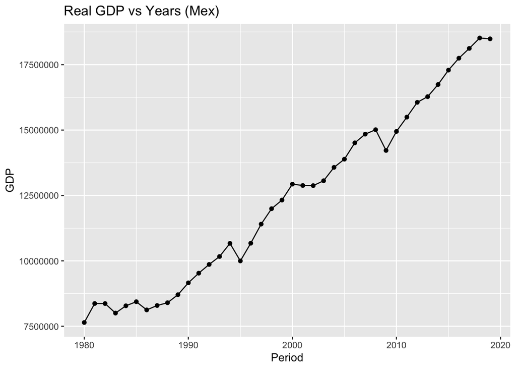

```r
rgdp_pop %>% ggplot(aes(Period, GDP)) +
  ggtitle("Real GDP vs Years (Mex)")+
  geom_point() + geom_line()
```

We see the real gross domestic product of Mexico, at constant prices of 2013 (Mexican pesos), has increased considerably since 1980. We now need to compute the real gross internal product per capita.

```r
r_GDP_pc <- rgdp_pop[,"GDP"]/rgdp_pop[,"Population"] #We create a variable of the real GDP per capita
n_rgdp_pop <- cbind(rgdp_pop, r_GDP_pc) #We create a new data frame
head(n_rgdp_pop)
```

|  | Period | GDP | Population | r_GDP_pc |
| --- | --- | --- | --- | --- |
| 1 | 1980 | 7642962 | 67761372 | 0.1127923 |
| 2 | 1981 | 8368150 | 69407624 | 0.1205653 |
| 3 | 1982 | 8367516 | 71058654 | 0.1177551 |
| 4 | 1983 | 8002443 | 72709299 | 0.1100608 |
| 5 | 1984 | 8281465 | 74352631 | 0.1113809 |
| 6 | 1985 | 8437038 | 75983485 | 0.1110378 |

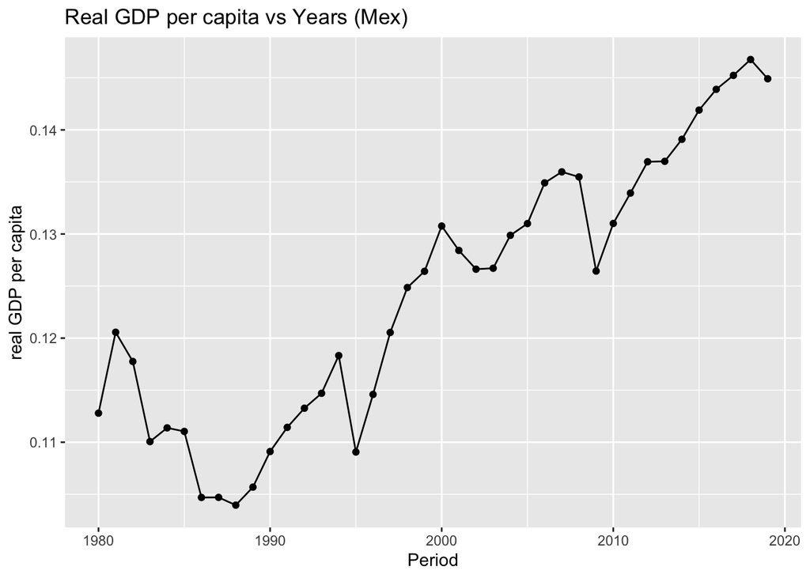

```r
#Let's make a plot
n_rgdp_pop %>% ggplot(aes(Period, r_GDP_pc)) +
  ggtitle("Real GDP per capita vs Years (Mex)")+
  ylab("real GDP per capita")+
  geom_point() + geom_line()
```

The plot suggests that between 1981 and 1988 perhaps the real GDP was shrinking, or it was not growing as fast as the population. However, from 1989 to 2019, although it has some fluctuations, the curve increased.

To answer how it is increasing, we must compute the growth rate of both real GDP and real GDP per capita using the below formula.

$$r=\frac{GDP_f-GDP_i}{GDP_i}·100$$

```r
i <- 1
f <- 2
GDP_r <- c()#GDP rate variable
year <- c()#year variable
for (j in 1:39){
  v <- (n_rgdp_pop[f,"GDP"]-n_rgdp_pop[i,"GDP"])/(n_rgdp_pop[i,"GDP"])*100#We compute
  GDP_r <- append(GDP_r, v) #We append
  year <- append(year, n_rgdp_pop[f,"Period"]) #We append
  i <- i+1 #This variable needs to increase by one
  f <- f+1 #This variable needs to increase by one
}
GDP_ra <- cbind(GDP_r, year)
head(GDP_ra)
```

```
##             GDP_r year
## [1,]  9.488312409 1981
## [2,] -0.007583372 1982
## [3,] -4.362980610 1983
## [4,]  3.486711357 1984
## [5,]  1.878577161 1985
## [6,] -3.708327140 1986
```

Now let’s do the same thing for the real GDP per capita

```r
i <- 1
f <- 2
GDPpc_r <- c()#GDP per capita rate variable
for (j in 1:39){
  v <- (n_rgdp_pop[f,"r_GDP_pc"]-n_rgdp_pop[i,"r_GDP_pc"])/(n_rgdp_pop[i,"r_GDP_pc"])*100#We compute
  GDPpc_r <- append(GDPpc_r, v)#We append
  i <- i+1 #This variable needs to increase by one
  f <- f+1#This variable needs to increase by one
}
GDP_ra <- as.data.frame(cbind(GDP_ra, GDPpc_r))
head(GDP_ra)
```

|  | GDP_r | year | GDPpc_r |
| --- | --- | --- | --- |
| 1 | 9.488312409 | 1981 | 6.8914024 |
| 2 | -0.007583372 | 1982 | -2.3308821 |
| 3 | -4.362980610 | 1983 | -6.5341302 |
| 4 | 3.486711357 | 1984 | 1.1994618 |
| 5 | 1.878577161 | 1985 | -0.3080702 |
| 6 | -3.708327140 | 1986 | -5.7131195 |

Let’s see how the real GDP rate has evolved over time.

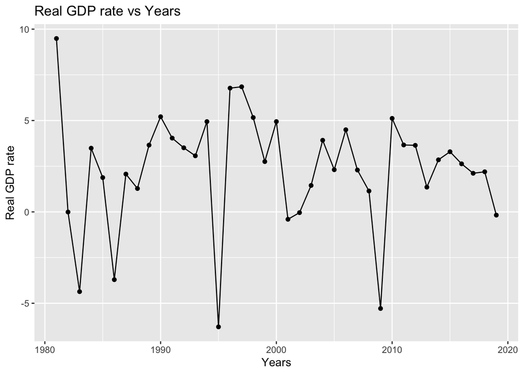

```r
GDP_ra %>% ggplot(aes(year, GDP_r))+
  xlab("Years")+
  ylab("Real GDP rate")+
  ggtitle("Real GDP rate vs Years")+
  geom_point()+geom_line()
```

Based on the graph, Mexico has not have a rate that suggests constant growth, meaning it fluctuates and doesn’t seem to stay at constant rate.

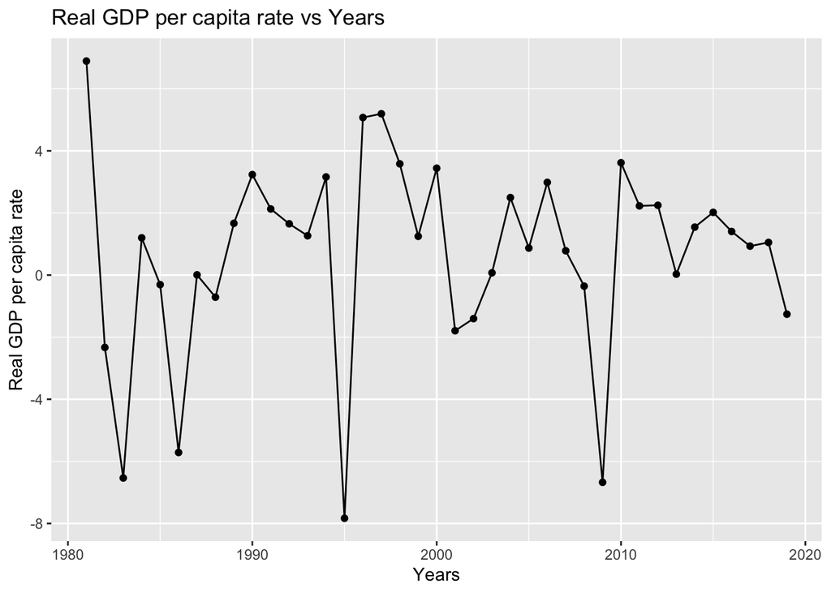

```r
GDP_ra %>% ggplot(aes(year, GDPpc_r))+
  xlab("Years")+
  ylab("Real GDP per capita rate")+
  ggtitle("Real GDP per capita rate vs Years")+
  geom_point()+geom_line()
```

The real GDP per capita rate has the same pattern of growth as the real GDP rate. Let’s compare both graphs side by side.

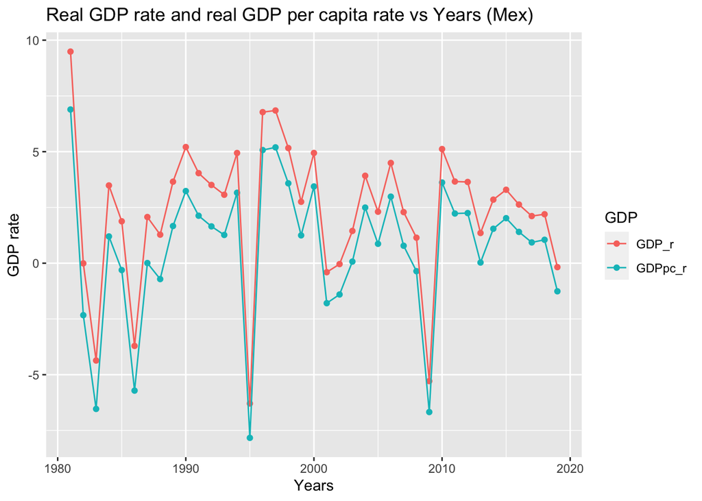

```r
GDP_ra %>% gather(key="GDP", value = GDPpc_r, -year) %>% #We elongate the data (the column GDPpc_r has all the rates)
  ggplot(aes(year, GDPpc_r, col=GDP))+ #x=years, y=GDPpc_r, and the color will be based on the GDP, which labels if it is real GDP rate or real GDP per capita rate
  xlab("Years")+
  ylab("GDP rate")+
  ggtitle("Real GDP rate and real GDP per capita rate vs Years (Mex)")+
  geom_point()+geom_line()
```

The real GDP per capita rate is smaller across the years than the real GDP rate. Let

$$r_{GDPpc}=\frac{\frac{GDP_n}{N_α}-\frac{GDP_{n-1}}{N_ß}}{\frac{GDP_{n-1}}{N_ß}}·100$$

be the real GDP per capita equation. If we start to develop the equation, we get

$$r_{GDPpc}=(\frac{\frac{GDP_n}{N_α}}{\frac{GDP_{n-1}}{N_ß}}-1)·100$$

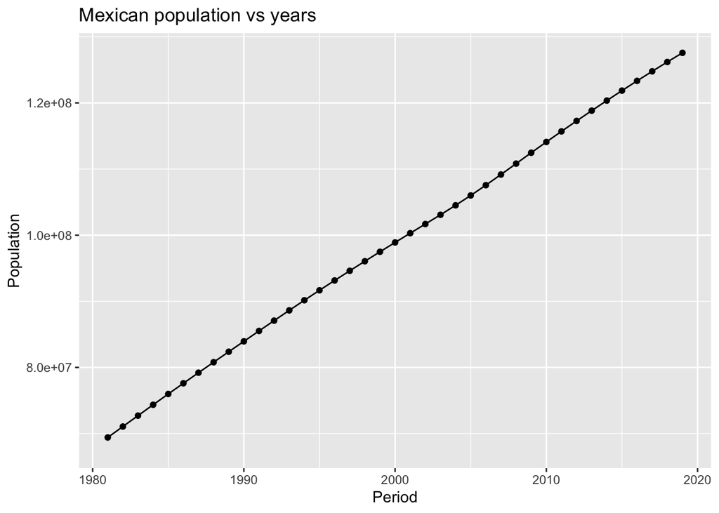

```r
n_rgdp_pop %>% ggplot(aes(Period, Population))+xlim(1981, 2019)+ggtitle("Mexican population vs years")+
  geom_point()+geom_line()
```

As we can see by the plot, the mexican population has indeed increased.

The only way for the real GDP per capita rate to be greater than the real GDP rate, is for the Mexican population to dicrease or not increase so rapidly, followed (preferably) by a significant increase in the real GDP of year n.

REFERENCES

1] Parkin, M. (2018). Economía. Twelfth Edition. Mexico: Pearson. pp 497-498.

[2] www.inegi.org.mx. (n.d.). Tabulados. [online] Disponible en: https://www.inegi.org.mx/app/tabulados/default.aspx?pr=38&vr=5&in=2&tp=20&wr=1&cno=2 [Accessed 28 May 2021].

[3] data.worldbank.org. (n.d.). Population, total - Mexico | Data. [online] Available at: https://data.worldbank.org/indicator/SP.POP.TOTL?view=chart&locations=MX [Accessed 28 May 2021].